Copyright © [Jeffrey A. Walker](https://github.com/middleprofessor)

[Back to R doodles](https://rdoodles.rbind.io)

# How to make plots with a grid of factor levels below the x-axis (bench-biology style)

Jeffrey A. Walker

12/25/2020

```r
knitr::opts_chunk$set(echo = TRUE,
                      message=FALSE,
                      warning=FALSE)
library(here)
library(janitor)
library(readxl)
library(data.table)

# graphics and tables
library(ggplot2)
library(ggpubr)
library(ggsci)
library(ggforce)
library(ggthemes)
library(cowplot)
library(kableExtra)
library(lazyWeave) #pvalstring

# analysis packages
library(emmeans)

pal_okabe_ito <- colorblind_pal()(8)[2:8] # ggthemes
pal_okabe_ito_blue <- pal_okabe_ito[c(5,6,1,2,3,7,4)]
pal_okabe_ito_red <- pal_okabe_ito[c(6,5,3,1,2,7,4)]
pal_okabe_ito_4 <- pal_okabe_ito[c(5,6,7,2)]

minus <- "\u2013"

here <- here::here
data_folder <- "content/data"
output_folder <- "content/output"
```

The motivation for this post was to create a pipeline for generating publication-ready plots entirely within ggplot and avoid post-generation touch-ups in Illustrator or Inkscape. These scripts are a start. The ideal modification would be turning the chunks into functions with personalized detail so that a research team could quickly and efficiently generate multiple plots. I might try to turn the scripts into a very-general-but-not-ready-for-r-package function for my students.

# 1 Background

The example data are from Figure 4b of

[Gómez-Banoy, Nicolás, et al. “Adipsin preserves beta cells in diabetic mice and associates with protection from type 2 diabetes in humans.” Nature medicine 25.11 (2019): 1739-1747.](https://www.nature.com/articles/s41586-019-0895-y)

The design is $2 \times 2$ factorial – there are two factor variables each with two levels. The goal is to create a $2 \times 4$ grid of the factor levels below the plot. The rows of the grid contain the values (levels) for each of the two factor variables. The columns of the grid contain the values (levels) of each factor for each of the four groups. I probably wouldn’t communicate treatments this way but it does have the advantage that treatment combinations are easy to see even if the plot were black-and-white (but why would anyone use black and white in 2020?).

# 2 Outline of Methods

1. Method 1 – the plot is generated as two plots that are stacked one on top of the other using `plot_grid()` from the cowplot package. The top plot is the plot of the data and modeled means and 95% CIs. The bottom plot contains only the grid of factor levels.
2. Method 2 – the grid of factor levels is plotted within the plot area (within the axes). This requires hiding the true plot axes and creating new axes, so that the grid appears below the x-axis line.
3. Method 3 – Using the x-axis tick labels for the grid. In order to create variable names for these rows, we need a new x-axis tick and in order to do this in a way that looks nice, we need to have a continous and not discrete x-axis. This is actually really easy.

My preference – Each method has pros and cons. I think method 3 has the most upside and effectively zero downsids, at least if you’re comfortable with making the plot with a continuous x-axis. This is easy if you understand the numeric values underneath a ggplot discrete x-axis.

```r
data_from <- "Adipsin preserves beta cells in diabetic mice and associates with protection from type 2 diabetes in humans"
fig_4_file <- "41591_2019_610_MOESM6_ESM.xlsx"
file_path <- here(data_folder, data_from, fig_4_file)

fig4 <- read_excel(file_path,
                   range = "A5:S5",
                   sheet = "Fig 4b",
                   col_names = FALSE) %>%
  data.table() %>%
  transpose()
colnames(fig4)[1] <- "tunel"

# populate factor columns
nsc_levels <- c("nsc_neg", "nsc_pos")
fig4[, nsc := c(rep(nsc_levels, c(5,5)),
                rep(nsc_levels, c(5,4)))]

pa_levels <- c("pa_neg", "pa_pos")
fig4[, palmitate := rep(pa_levels, c(10, 9))]

# convert to factor
fig4[, nsc := factor(nsc,
                     levels = nsc_levels)]
fig4[, palmitate := factor(palmitate,
                           levels = pa_levels)]


treatment_levels <- c("vehicle", "nsc87877", "palmitate", "nsc87877+palmitate")
fig4[, treatment := rep(treatment_levels, c(5,5,5,4))]
# convert to factor
fig4[, treatment := factor(treatment,
                           levels = treatment_levels)]

# View(fig4)
```

```r
m1 <- lm(tunel ~ nsc * palmitate, data = fig4)

# replicate
# t.test(tunel ~ palmitate,
#        data = fig4[nsc == "nsc_neg"],
#        var.equal = FALSE)

# data for plots

m1_coef <- cbind(coef(summary(m1)),
                 confint(m1))

m1_emm <- emmeans(m1, specs = c("nsc", "palmitate"))
m1_simple <- contrast(m1_emm,
                      method = "revpairwise",
                      simple = "each",
                      combine = TRUE,
                      adjust = "none") %>%
  summary(infer = TRUE)
```

# 3 Base-plot

## 3.1 show the data

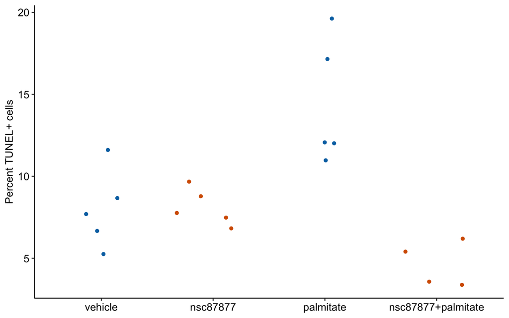

```r
fig4_base <- ggplot(data = fig4,
                    aes(x = treatment,
                        y = tunel,
                        color = nsc)) +
  # show the data
  geom_sina() +
  # geom_dotplot(binaxis='y',
  #              stackdir='center',
  #              alpha = 0.5) +

  # x and y axis labels
  ylab("Percent TUNEL+ cells") +


  theme_pubr() +
  theme(legend.position="none",
        axis.title.x=element_blank()) +
  scale_color_manual(values = pal_okabe_ito_blue) +

  NULL

fig4_base
```

## 3.2 Show the model – Adding modeled means and error intervals

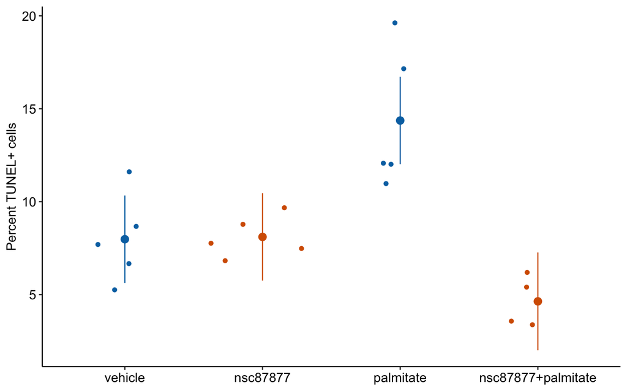

```r
# need mean and ci from emmeans table
m1_emm_dt <- m1_emm %>%
  summary() %>%
  data.table()
# add treatment column for plot
m1_emm_dt[, treatment := treatment_levels]
# m1_emm_dt # check

fig4_response <- fig4_base +
    # show the model
  geom_point(data = m1_emm_dt,
             aes(y = emmean),
             size = 3) +

  geom_errorbar(data = m1_emm_dt,
             aes(y = emmean,
                 ymin = lower.CL,
                 ymax = upper.CL),
             width = 0)

fig4_response
```

## 3.3 Add p-value bracket

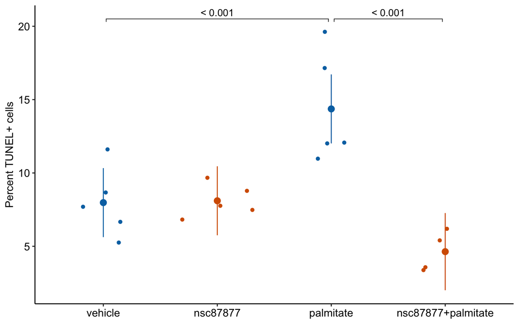

```r
# p-values come from contrast table

m1_simple_dt <- m1_simple %>%
  data.table()
# m1_emm_dt[, treatment]
# "vehicle", "nsc87877", "palmitate", "nsc87877+palmitate"
m1_simple_dt[, group1 := c("nsc87877",
                          "nsc87877+palmitate",
                          "palmitate",
                          "nsc87877+palmitate")]
m1_simple_dt[, group2 := c("vehicle",
                          "palmitate",
                          "vehicle",
                          "nsc87877")]

m1_simple_dt[, p_pretty := pvalString(p.value)]

rows <- c(2, 3)
y_start <- 20.5
y_inc <- 1
y_position <- c(y_start, y_start)

fig4_response <- fig4_response +
  stat_pvalue_manual(m1_simple_dt[rows],
                     label = "p_pretty",
                     y.position = y_position,
                     tip.length = 0.01,
                     bracket.shorten = -0.05)
fig4_response
```

# 4 Method 1: Creating a separate grid of treatments and arranging with cowplot

1. Pros
- nice control of the treatment grid (as two-way grid or hierarchical)
2. Cons
- no longer a ggplot so cannot add ggplot features
- can create issues of aligning axes with other plots using cowplot

## 4.1 Variant 1 – A two-way table of treatments

**create the plot of the grid of treatments**

```r
nsc_values <- c(minus, "+", minus, "+")
pa_values <- c(minus, minus, "+", "+")
v_base <- 1
v_sep <- 0.5
v_breaks <- c(v_base + v_sep, v_base)
v_lims <- c(v_base, v_base + v_sep) + c(-v_sep/2, v_sep/2)
txt_size = 5

# starts with fig4_base to automate position of treatment levels
# but hides everything in fig_4_base by plotting below all y-values
# if overlap with y-values, just make v_base above more negative
# alternative is to get x positions using
# x_pos <- ggplot_build(gg)$data[[2]][, "x"]

fig4_table_1 <- fig4_base +
   annotate(geom = "text",
           label = nsc_values,
           x = 1:4,
           y = v_breaks[1],
           size = txt_size) +
  annotate(geom = "text",
           label = pa_values,
           x = 1:4,
           y = v_breaks[2],
           size = txt_size) +
  coord_cartesian(ylim = v_lims) +
  theme(axis.title = element_blank(),
        axis.text.x = element_blank(),
        axis.ticks = element_blank(),
        panel.grid = element_blank(),
        axis.line = element_blank(),
        panel.background = element_blank(),
        plot.margin = unit(c(0, 0, 0, 0), "pt")) +
  scale_y_continuous(breaks = v_breaks,
                     labels = c("NSC-87877",
                                "palmitate")) +
  NULL
```

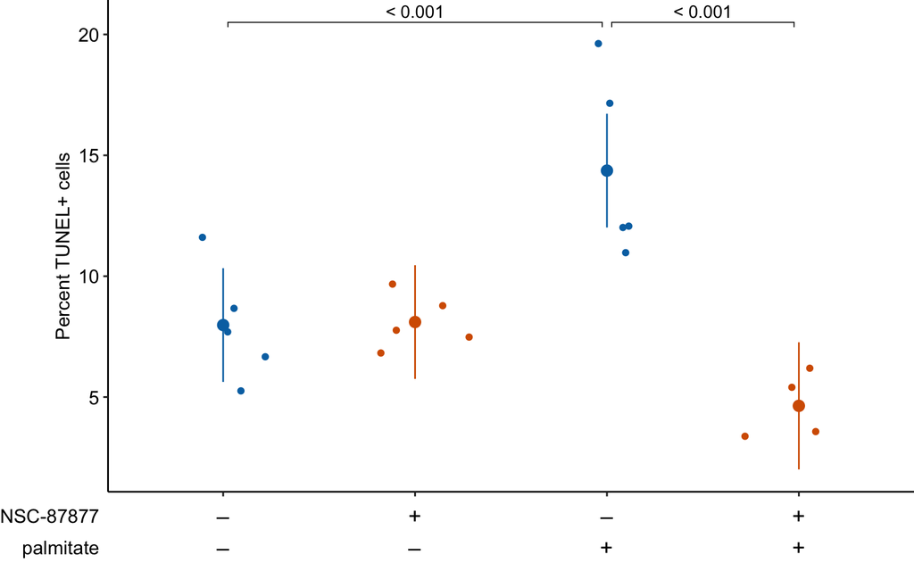

```r
# remove stuff from fig4_response
fig4_response_mod <- fig4_response +
  theme(axis.text.x = element_blank(),
        plot.margin = unit(c(0, 0, 0, 0), "pt")) +
  NULL

fig4_method1_v1 <- plot_grid(fig4_response_mod,
                             fig4_table_1,
                             nrow = 2,
                             rel_heights = c(1, 0.15),
                             align = "v",
                             axis = "lr")
fig4_method1_v1
```

## 4.2 Variant 2 – A hierarchical table of treatments

```r
nsc_values <- c(paste("NSC-87877", minus),
                paste("NSC-87877", "+"),
                paste("NSC-87877", minus),
                paste("NSC-87877", "+"))
pa_values <- c(paste("Pa", minus), "Pa +")
v_base <- 1
v_sep <- 0.5
v_breaks <- c(v_base + v_sep, v_base)
v_lims <- c(v_base, v_base + v_sep) + c(-v_sep/2, v_sep/2)
txt_size = 4
fudge <- 0.3
line_size <- 0.8

fig4_table_2 <- fig4_base +
  annotate(geom = "text",
           label = nsc_values,
           x = 1:4,
           y = v_breaks[1],
           size = txt_size) +
  annotate(geom = "text",
           label = pa_values,
           x = c(1.5, 3.5),
           y = v_breaks[2],
           size = txt_size) +
  geom_segment(aes(x = 1-fudge,
              y = sum(v_breaks)/2,
              xend = 2+fudge,
              yend = sum(v_breaks)/2),
              color = "black",
              size = line_size) +
  geom_segment(aes(x = 3-fudge,
              y = sum(v_breaks)/2,
              xend = 4+fudge,
              yend = sum(v_breaks)/2),
              color = "black",
              size = line_size) +
  coord_cartesian(ylim = v_lims) +
  theme(axis.title = element_blank(),
        axis.text.x = element_blank(),
        axis.ticks = element_blank(),
        panel.grid = element_blank(),
        axis.line = element_blank(),
        panel.background = element_blank(),
        plot.margin = unit(c(0, 0, 0, 0), "pt")) +
  scale_y_continuous(breaks = v_breaks,
                     labels = c("",
                                "")) +
  NULL
```

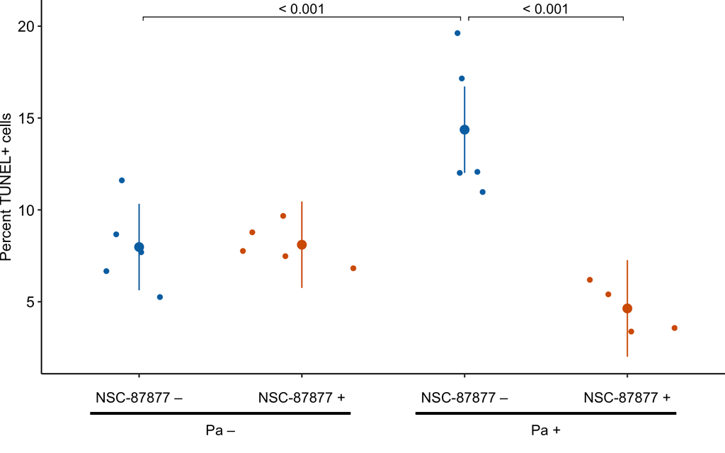

```r
# remove stuff from fig4_response
fig4_response_mod <- fig4_response +
  theme(axis.text.x = element_blank(),
        plot.margin = unit(c(0, 0, 0, 0), "pt")) +
  NULL

fig4_method1_v1 <- plot_grid(fig4_response_mod,
                             fig4_table_2,
                             nrow = 2,
                             rel_heights = c(1, 0.2),
                             align = "v",
                             axis = "lr")

fig4_method1_v1
```

# 5 Method 2 – Plotting the table inside the plot area

1. Pros
- the final plot is a ggplot and can be modified further.
2. Cons
- the actual x-axis is below the table and this can screw up arranging with cowplot.
- kinda kludgy

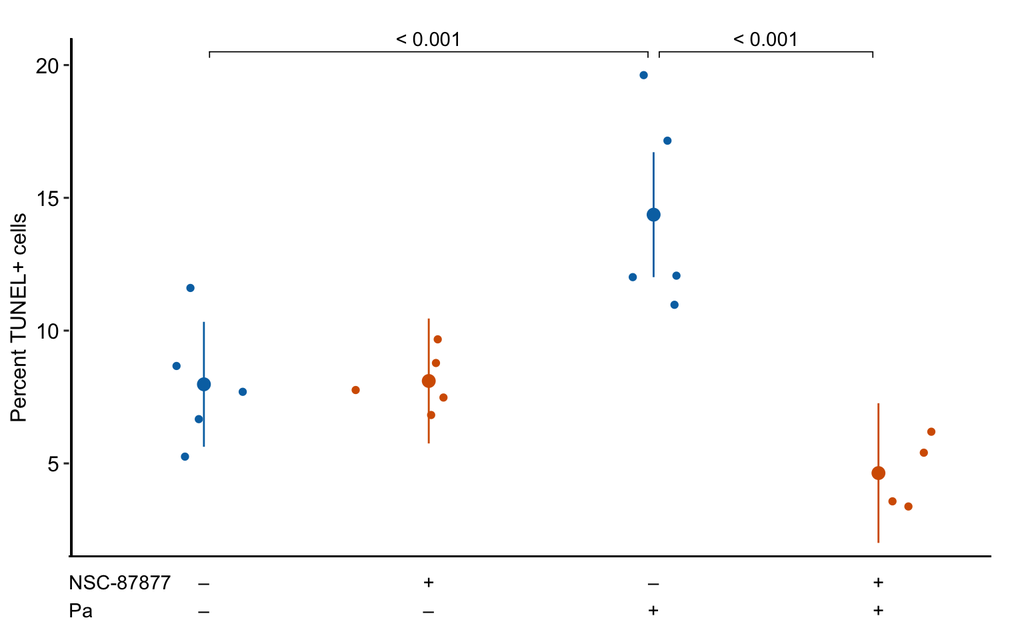

```r
x_levels <- rbind(
  "NSC-87877" = c(minus, "+", minus, "+"),
  "Pa" = c(minus, minus, "+", "+")
)

x_levels_text <- apply(x_levels, 2, paste0, collapse="\n")
x_levels_title <- paste(row.names(x_levels), collapse="\n")

x_axis_min <- 0.4
x_axis_max <- 4.5
y_plot_min <- 0
y_axis_min <- 1.5
y_axis_max <- 21
y_breaks <- seq(5, 20, by = 5)
y_labels <- as.character(y_breaks)

fig4_method2 <- fig4_response +
  coord_cartesian(ylim = c(y_plot_min, y_axis_max)) +
  scale_y_continuous(breaks = y_breaks) +
  theme(
    axis.line = element_blank(), # remove both x & y axis lines
    axis.text.x = element_blank(), # remove x-axis labels
    axis.ticks.x = element_blank() # remove x-axis ticks
  ) +

  # add shortened y-axis line that doesn't extend to treatments
  geom_segment(aes(x = x_axis_min + 0.01,
                   y = y_axis_min,
                   xend = x_axis_min + 0.01,
                   yend = y_axis_max),
               size = 0.5,
               color = "black") +

  # add x-axis line above treatments
  geom_segment(aes(x = x_axis_min,
                   y = y_axis_min,
                   xend = x_axis_max,
                   yend = y_axis_min),
               size = 0.5,
               color = "black") +

  # add treatment combinations
  annotate(geom = "text",
           x = 1:4,
           y = y_plot_min,
           label = x_levels_text) +

  # add factor names
  annotate(geom = "text",
           x = x_axis_min,
           y = y_plot_min,
           label = x_levels_title,
           hjust = 0) +
  NULL

fig4_method2
```

# 6 Method 3 - Modify the x-axis labels

1. Pros
- total control
- the final object is a ggplot
- the axes are where they should be (as opposed to method 2)
- the position of the factor variable names is the nicest of the three methods
- should play nice with cowplot
2. Cons
- the user has to build the plot using non-standard methods for a categorical x-axis (easy enough if you understand a ggplot)
- users need to recognize the x-axis is continous and not discrete when additing additional components
3. Thoughts
- note that cannot use the discrete x-axis plot as the base because cannot add non-integer breaks (or even expand breaks?) to include the factor variable names
- can this be solved by starting with the original discrete x-axis and changing to continous using `build`?

## 6.1 Variant 1 – rebuild plot from scratch with continuous X axis

Add integer group assignment and jittered x to data

```r
# need m1_emm_dt and m1_simple_dt from previous chunks

set.seed(1) # maintain jitter
N <- nrow(fig4)
jitter_width <- 0.4
fig4[, treatment_i := as.integer(treatment)]
fig4[, treatment_x := treatment_i +
       runif(N, -jitter_width/2, jitter_width/2)]

# treatment_x needs to be added to m1_emm_dt
m1_emm_dt[, treatment_x := 1:4]

# m1_simple_dt needs numeric positions for p-value bracket
m1_simple_dt[, group1_i := c(2,4,3,4)]
m1_simple_dt[, group2_i := c(1,3,1,2)]
```

Create the base plot with a continuous x-axis

```r
# this requires objects created in earlier chunks

fig4_method3_base <- ggplot(data = fig4,
                            aes(x = treatment_x,
                                y = tunel,
                                color = nsc)) +
  # show the data
  geom_point() +

  # add modeled mean
  geom_point(data = m1_emm_dt,
             aes(y = emmean),
             size = 3) +

  # add modeled CI
  geom_errorbar(data = m1_emm_dt,
                aes(y = emmean,
                    ymin = lower.CL,
                    ymax = upper.CL),
                width = 0) +

# x and y axis labels
  ylab("Percent TUNEL+ cells") +

  stat_pvalue_manual(m1_simple_dt[rows],
                     label = "p_pretty",
                     xmax = "group2_i",
                     xmin = "group1_i",
                     y.position = y_position,
                     tip.length = 0.01,
                     bracket.shorten = -0.05) +

  theme_pubr() +
  theme(legend.position="none",
        axis.title.x=element_blank()) +
  scale_color_manual(values = pal_okabe_ito_blue) +

NULL

show_the_base_plot <- FALSE
if(show_the_base_plot == TRUE){fig4_method3_base}
```

Add the treatment grid

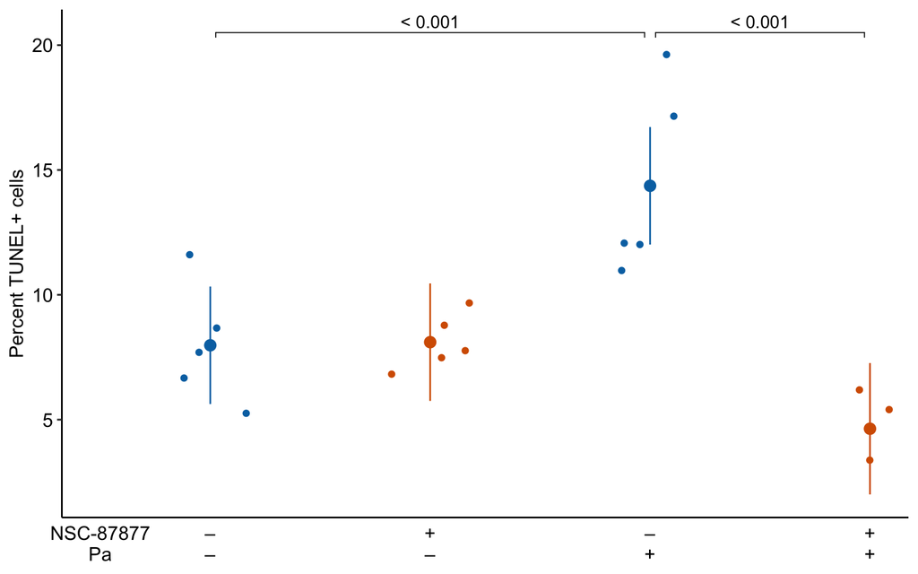

```r
x_levels <- rbind(
  c("NSC-87877", minus, "+", minus, "+"),
  c("Pa", minus, minus, "+", "+")
)

x_breaks_text <- apply(x_levels, 2, paste0, collapse="\n")
x_breaks <- c(0.5, 1:4)

fig4_method3 <- fig4_method3_base +
  coord_cartesian(xlim = c(0.5, 4)) +
  scale_x_continuous(breaks = x_breaks,
                     labels = x_breaks_text) +
  theme(axis.ticks.x = element_blank()) + # remove x-axis ticks

  NULL

fig4_method3
```

# 7 Combining the treatment grid with a traditional factorial plot

## 7.1 Method 1

### 7.1.1 Base factorial plot

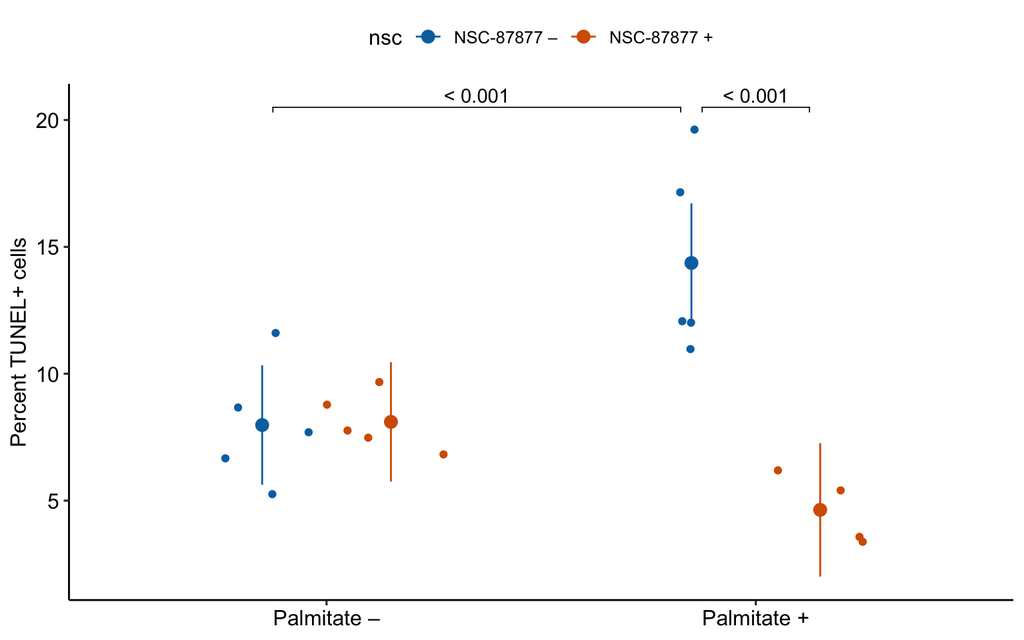

```r
pd_width <- 0.6
pd <- position_dodge(pd_width)
fig4_factorial_m1_base <- ggplot(data = fig4,
                                 aes(x = palmitate,
                                     y = tunel,
                                     color = nsc)) +
  # show the data
  geom_sina(position = pd) +
  # geom_dotplot(binaxis='y',
  #              stackdir='center',
  #              alpha = 0.5) +

  # x and y axis labels
  ylab("Percent TUNEL+ cells") +

  # show the model
  geom_point(data = m1_emm_dt,
             aes(y = emmean),
             size = 3,
             position = pd) +

  geom_errorbar(data = m1_emm_dt,
             aes(y = emmean,
                 ymin = lower.CL,
                 ymax = upper.CL),
             width = 0,
             position = pd) +

  theme_pubr() +
  theme(legend.position="top",
        axis.title.x=element_blank()) +
  scale_color_manual(values = pal_okabe_ito_blue,
                     labels = c(paste("NSC-87877", minus),
                                "NSC-87877 +")) +
  scale_x_discrete(labels = c(paste("Palmitate", minus),
                                "Palmitate +")) +

  NULL

# needs m1_simple_dt from earlier chunk

# the treatments are now organized 2 x 2 instead of flattened
# this complicates the use of stat_pvalue_manual
# "vehicle", "nsc87877", "palmitate", "nsc87877+palmitate"
m1_simple_dt[, x_min_col := c(1 + pd_width/4,
                         2 + pd_width/4,
                         2 - pd_width/4,
                         2 + pd_width/4)]
m1_simple_dt[, x_max_col := c(1 - pd_width/4,
                         2 - pd_width/4,
                         1 - pd_width/4,
                         1 + pd_width/4)]

y_position <- c(y_start, y_start)

fig4_factorial_m1_p <- fig4_factorial_m1_base +
  stat_pvalue_manual(m1_simple_dt[rows],
                     label = "p_pretty",
                     y.position = y_position,
                     xmax = "x_max_col",
                     xmin = "x_min_col",
                     tip.length = 0.01,
                     bracket.shorten = -0.05)

fig4_factorial_m1_p
```

### 7.1.2 Adding the table of treatments using cowplot

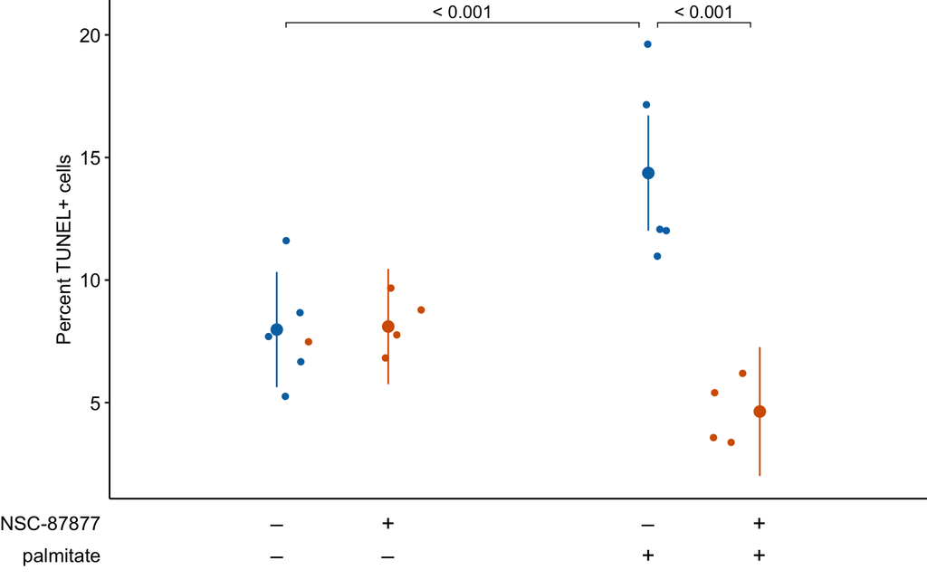

```r
# remove stuff from base plot
fig4_factorial_m1_p <- fig4_factorial_m1_p +
  theme(legend.position="none",
        axis.text.x = element_blank(),
        axis.ticks.x = element_blank(),
        plot.margin = unit(c(0, 0, 0, 0), "pt")) +
  NULL

nsc_values <- c(minus, "+", minus, "+")
pa_values <- c(minus, minus, "+", "+")
v_base <- 1
v_sep <- 0.5
v_breaks <- c(v_base + v_sep, v_base)
v_lims <- c(v_base, v_base + v_sep) + c(-v_sep/2, v_sep/2)
txt_size = 5

# Again -- starts with fig4_factorial_m1_base to automate position of
# treatment levels
# but hides everything in fig_4_base by plotting below all y-values
# if overlap with y-values, just make v_base above more negative
# alternative is to get x positions using
# x_pos <- ggplot_build(gg)$data[[2]][, "x"]

fig4_factorial_m1_table <- fig4_factorial_m1_base +
   annotate(geom = "text",
           label = nsc_values,
           x = c(1 - pd_width/4,
                 1 + pd_width/4,
                 2 - pd_width/4,
                 2 + pd_width/4),
           y = v_breaks[1],
           size = txt_size) +
  annotate(geom = "text",
           label = pa_values,
           x = c(1 - pd_width/4,
                 1 + pd_width/4,
                 2 - pd_width/4,
                 2 + pd_width/4),
           y = v_breaks[2],
           size = txt_size) +
  coord_cartesian(ylim = v_lims) +
  theme(legend.position="none",
        axis.title = element_blank(),
        axis.text.x = element_blank(),
        axis.ticks = element_blank(),
        panel.grid = element_blank(),
        axis.line = element_blank(),
        panel.background = element_blank(),
        plot.margin = unit(c(0, 0, 0, 0), "pt")) +
  scale_y_continuous(breaks = v_breaks,
                     labels = c("NSC-87877",
                                "palmitate")) +
  NULL

fig4_factorial_method1 <- plot_grid(fig4_factorial_m1_p,
                                    fig4_factorial_m1_table,
                                    nrow = 2,
                                    rel_heights = c(1, 0.15),
                                    align = "v",
                                    axis = "lr")

fig4_factorial_method1
```

## 7.2 Method 3

Add dodged group assignment and jittered x to data

```r
# need m1_emm_dt and m1_simple_dt from previous chunks

set.seed(1) # maintain jitter
N <- nrow(fig4)
dodge_width <- 0.3
jitter_width <- 0.2
fig4[, treatment_i := as.integer(treatment)]

# x position of group means
x_pos <- c(1 - dodge_width/2,
           1 + dodge_width/2,
           2 - dodge_width/2,
           2 + dodge_width/2)
fig4[, treatment_x_mean := x_pos[treatment_i]]

# x position of jittered points
fig4[, treatment_x := treatment_x_mean + runif(N, -jitter_width/2, jitter_width/2)]

# treatment_x needs to be added to m1_emm_dt
m1_emm_dt[, treatment_x := x_pos]

# m1_simple_dt needs numeric positions for p-value bracket

# use x positions in m1_emm_dt to set these
m1_simple_dt[, group1_i := c(x_pos[2],
                             x_pos[4],
                             x_pos[3],
                             x_pos[4])]
m1_simple_dt[, group2_i := c(x_pos[1],
                             x_pos[3],
                             x_pos[1],
                             x_pos[2])]
```

Create the base plot with a continuous x-axis

```r
# this requires objects created in earlier chunks

fig4_factorial_method3_base <- ggplot(data = fig4,
                            aes(x = treatment_x,
                                y = tunel,
                                color = nsc)) +
  # show the data
  geom_point() +

  # add modeled mean
  geom_point(data = m1_emm_dt,
             aes(y = emmean),
             size = 3) +

  # add modeled CI
  geom_errorbar(data = m1_emm_dt,
                aes(y = emmean,
                    ymin = lower.CL,
                    ymax = upper.CL),
                width = 0) +

# x and y axis labels
  ylab("Percent TUNEL+ cells") +

  stat_pvalue_manual(m1_simple_dt[rows],
                     label = "p_pretty",
                     xmax = "group2_i",
                     xmin = "group1_i",
                     y.position = y_position,
                     tip.length = 0.01,
                     bracket.shorten = -0.05) +

  theme_pubr() +
  theme(legend.position="none",
        axis.title.x=element_blank()) +
  scale_color_manual(values = pal_okabe_ito_blue) +

NULL

show_the_base_plot <- FALSE
if(show_the_base_plot == TRUE){fig4_factorial_method3_base}
```

Add the treatment grid

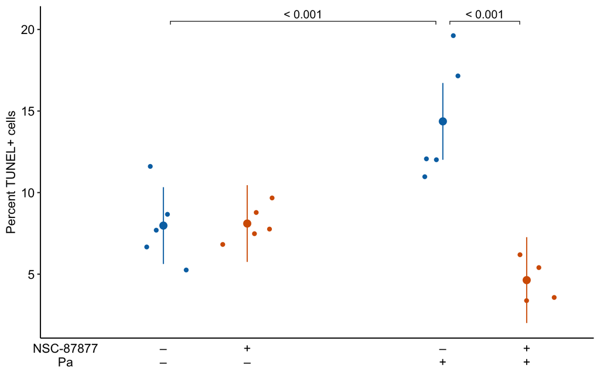

```r
x_levels <- rbind(
  c("NSC-87877", minus, "+", minus, "+"),
  c("Pa", minus, minus, "+", "+")
)

x_min <- 0.5
x_max <- 2 + dodge_width
x_breaks_text <- apply(x_levels, 2, paste0, collapse="\n")
x_breaks <- c(x_min, x_pos)

fig4_factorial_method3 <- fig4_factorial_method3_base +
  coord_cartesian(xlim = c(x_min, x_max)) +
  scale_x_continuous(breaks = x_breaks,
                     labels = x_breaks_text) +
  theme(axis.ticks.x = element_blank()) + # remove x-axis ticks

  NULL

fig4_factorial_method3
```